# Machine Learning: Classifying Yeast Protiens

### Section 1: Import Libraries/Dataset

#### Step 1: Import Libraries

```python
# Import Libraries
%matplotlib inline
import matplotlib.pyplot as plt
plt.style.use('seaborn-white')
import pandas as pd
import numpy as np
import seaborn as sns
from sklearn.preprocessing import StandardScaler
from sklearn.ensemble import RandomForestClassifier
from sklearn.inspection import permutation_importance
from scipy.stats import zscore
from sklearn.model_selection import train_test_split
from sklearn.model_selection import KFold
from sklearn.linear_model import LogisticRegression
from sklearn.metrics import accuracy_score, precision_score, recall_score, f1_score,classification_report
```

#### Step 2: Read Dataset and create dataframes.

```python
# Add .csv file in the required location. Read the data set and create required dataframes.
df = pd.read_csv('yeast1.csv')
```

### Section 2: Data Visualization and Exploration

#### Step 1: Print 2 rows for sanity check to identify all the features present in the dataset and if the target matches with them

```python
# we check the dataset with pandas head method, with just top 2 elements
df.head(2)
```

|  | mcg | gvh | alm | mit | erl | pox | vac | nuc | name |
| --- | --- | --- | --- | --- | --- | --- | --- | --- | --- |
| 0 | 0.58 | 0.61 | 0.47 | 0.13 | 0.5 | 0.0 | 0.48 | 0.22 | MIT |
| 1 | 0.43 | 0.67 | 0.48 | 0.27 | 0.5 | 0.0 | 0.53 | 0.22 | MIT |

```python
# Perform sanity check on the dataset. Check for all record counts
df.info()
```

```
<class 'pandas.core.frame.DataFrame'>
RangeIndex: 1484 entries, 0 to 1483
Data columns (total 9 columns):
 #   Column  Non-Null Count  Dtype
---  ------  --------------  -----
 0   mcg     1484 non-null   float64
 1   gvh     1484 non-null   float64
 2   alm     1484 non-null   float64
 3   mit     1484 non-null   float64
 4   erl     1484 non-null   float64
 5   pox     1484 non-null   float64
 6   vac     1484 non-null   float64
 7   nuc     1484 non-null   float64
 8   name    1484 non-null   object
dtypes: float64(8), object(1)
memory usage: 104.5+ KB
```

```python
# Perform sanity check. Check for missing values if any.
df.isnull().sum()
```

```
mcg     0
gvh     0
alm     0
mit     0
erl     0
pox     0
vac     0
nuc     0
name    0
dtype: int64
```

**Based upon the above null check validation none of the records are missing or have null value.**

```python
# Perform sanity check. Check for description of the data
df.describe()
```

|  | mcg | gvh | alm | mit | erl | pox | vac | nuc |
| --- | --- | --- | --- | --- | --- | --- | --- | --- |
| count | 1484.000000 | 1484.000000 | 1484.000000 | 1484.000000 | 1484.000000 | 1484.000000 | 1484.000000 | 1484.000000 |
| mean | 0.500121 | 0.499933 | 0.500034 | 0.261186 | 0.504717 | 0.007500 | 0.499885 | 0.276199 |
| std | 0.137299 | 0.123924 | 0.086670 | 0.137098 | 0.048351 | 0.075683 | 0.057797 | 0.106491 |
| min | 0.110000 | 0.130000 | 0.210000 | 0.000000 | 0.500000 | 0.000000 | 0.000000 | 0.000000 |
| 25% | 0.410000 | 0.420000 | 0.460000 | 0.170000 | 0.500000 | 0.000000 | 0.480000 | 0.220000 |
| 50% | 0.490000 | 0.490000 | 0.510000 | 0.220000 | 0.500000 | 0.000000 | 0.510000 | 0.220000 |
| 75% | 0.580000 | 0.570000 | 0.550000 | 0.320000 | 0.500000 | 0.000000 | 0.530000 | 0.300000 |
| max | 1.000000 | 1.000000 | 1.000000 | 1.000000 | 1.000000 | 0.830000 | 0.730000 | 1.000000 |

#### Step 2: Comment on class imbalance with appropriate visualization method.

```python
# Value count on the basis of different types of protiens
data = df["name"].value_counts().head(50).to_frame()
data.index
data.head()
```

|  | name |
| --- | --- |
| CYT | 463 |
| NUC | 429 |
| MIT | 244 |
| ME3 | 163 |
| ME2 | 51 |

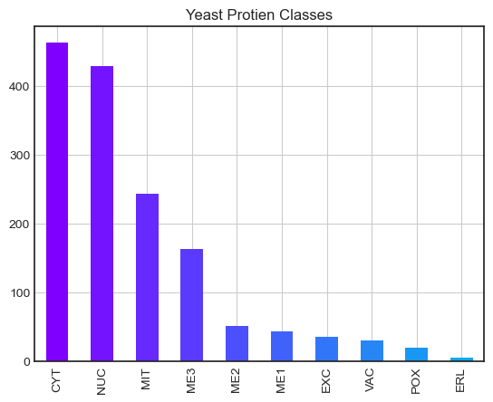

```python
# Histogram of different classes of yeast protien
df["name"].value_counts().head(50).plot.bar(color=plt.cm.rainbow(np.linspace(0,1,40)))
plt.title("Yeast Protien Classes")
plt.xticks(rotation=90)
plt.grid()
plt.show()
```

#### Step 3: Provide appropriate visualizations to get an insight about the dataset.

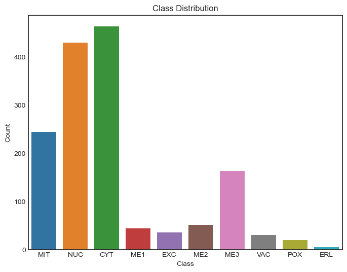

```python
# Insight visualization of the dataset. With Bar Plot

plt.figure(figsize=(8, 6))
sns.countplot(x='name', data=df)
plt.title('Class Distribution')
plt.xlabel('Class')
plt.ylabel('Count')
plt.show()
```

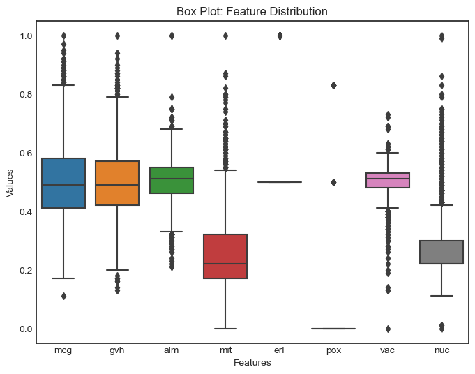

```python
# Insight Visualization with Box Plot.

plt.figure(figsize=(8, 6))
sns.boxplot(data=df.drop(columns='name'))
plt.title('Box Plot: Feature Distribution')
plt.xlabel('Features')
plt.ylabel('Values')
plt.show()
```

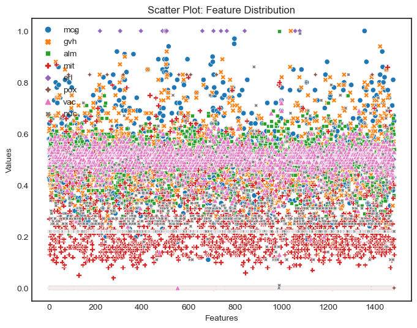

```python
# Insight Visualization with Scatter Plot.

plt.figure(figsize=(8, 6))
sns.scatterplot(data=df.drop(columns='name'))
plt.title('Scatter Plot: Feature Distribution')
plt.xlabel('Features')
plt.ylabel('Values')
```

#### Step 4: Do the correlational analysis on the dataset. Provide a visualization for the same. Will this correlational analysis have effect on feature selection that you will perform in the next step

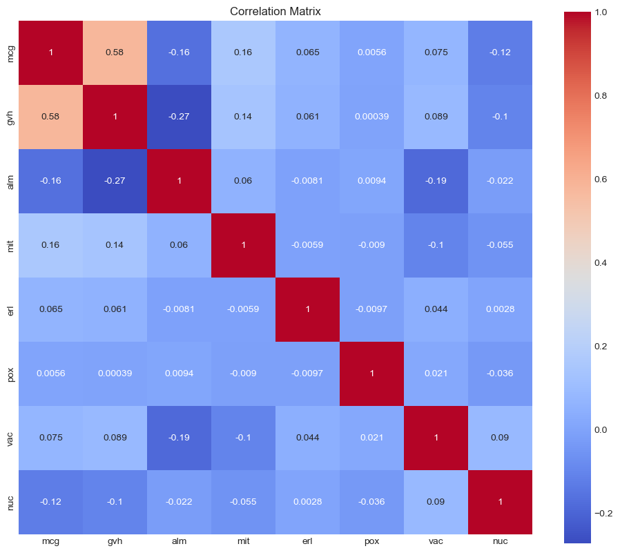

```python
# Correlation Matrix representation of data tells how different classes of data is placed.

plt.figure(figsize=(12,10))
correlation = df.drop(columns='name').corr()
sns.heatmap(correlation, annot=True, cmap='coolwarm',square=True)
plt.title('Correlation Matrix')
plt.show()
```

**Correlation Matrix helps in identifying features that are highly correlated with the target variable or with each other. Highly correlated features may provide redundant or duplicate information, and including them in the feature set may not significantly improve the models performance. In such cases, it is common to select a subset of features that are less correlated with each other and have a stronger correlation with the target variable. Correlational analysis assists in making informed decisions about feature selection and can improve the models interpretability and generalization capabilities.**

#### Step 5: Any other visualisation specific to the problem statement.

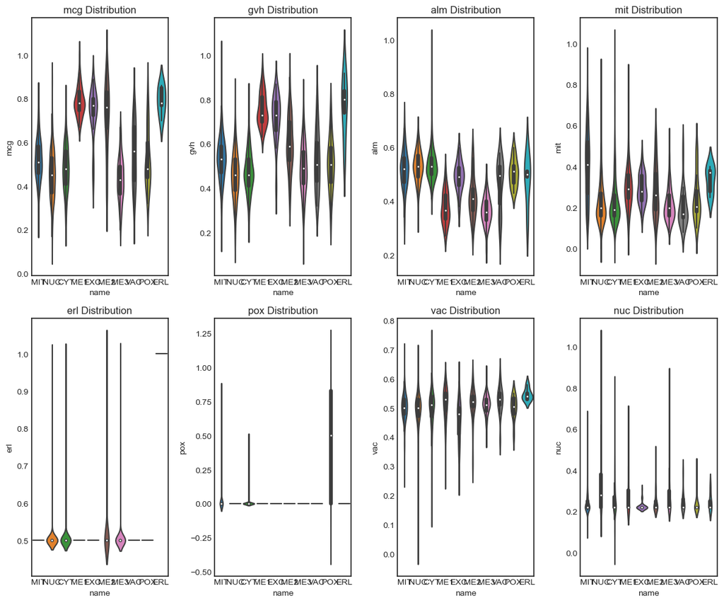

```python
# Based on the data we can generate violin plot. display the distribution of each feature's values,
# separated by the different classes of the target variable.This visualization helps in understanding
# the feature's distribution and its relationship with the target.

plt.figure(figsize=(12,10))
for feature in df.columns[:-1]:
    plt.subplot(2, 4, df.columns.get_loc(feature) + 1)
    sns.violinplot(x='name', y=feature, data=df)
    plt.title(f'{feature} Distribution')
plt.tight_layout()
plt.show()
```

### Section 3: Data Pre-processing and cleaning

#### Step 1: Do the appropriate pre-processing of the data like identifying NULL or Missing Values if any, handling of outliers if present in the dataset, skewed data etc. Mention the pre-processing steps performed in the markdown cell. Explore few latest data balancing tasks and its effect on model evaluation parameters

##### a. Handling Null or Missing values

```python
# Check for missing or null values

df.isnull().sum()
```

```
mcg     0
gvh     0
alm     0
mit     0
erl     0
pox     0
vac     0
nuc     0
name    0
dtype: int64
```

##### b. Handle Outliers

```python
# Handling outliers
Q1 = df.drop(columns='name').quantile(0.01)
Q3 = df.drop(columns='name').quantile(0.996)
lower_bound = Q1
upper_bound = Q3
```

```python
# Check the values of lowerbound and upper bound and see the outliers in the data
lower_bound
```

```
mcg    0.2300
gvh    0.2283
alm    0.2900
mit    0.0883
erl    0.5000
pox    0.0000
vac    0.3000
nuc    0.1100
Name: 0.01, dtype: float64
```

```python
upper_bound
```

```
mcg    0.91068
gvh    0.87068
alm    0.75000
mit    0.79068
erl    1.00000
pox    0.83000
vac    0.63340
nuc    0.75272
Name: 0.996, dtype: float64
```

```python
# Impact on data set
numerical_features = ["mcg","gvh","alm","mit","vac","nuc"]
df_numeric = df[(df[numerical_features] >= lower_bound) & (df[numerical_features] <= upper_bound)]
```

##### c. Address Skewed data

```python
skewed_features = ['mcg', 'gvh', 'alm', 'mit', 'vac', 'nuc']
df_numeric[skewed_features] = np.log1p(df_numeric[skewed_features])
```

##### d. Data Visualization after pre-processing

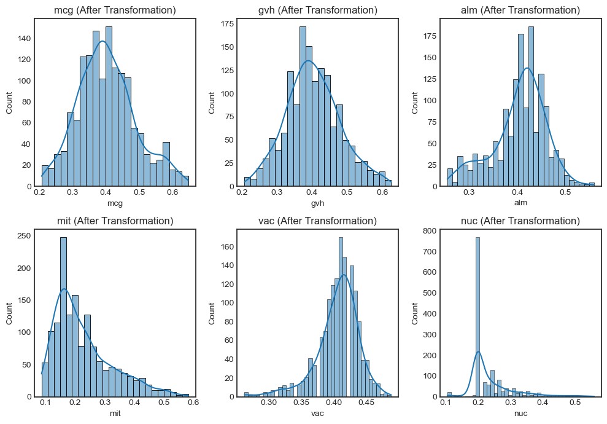

```python
plt.figure(figsize=(10,7))
for i, feature in enumerate(skewed_features, start=1):
    plt.subplot(2, 3, i)
    sns.histplot(df_numeric[feature], kde=True)
    plt.title(feature + " (After Transformation)")
plt.tight_layout()
plt.show();
```

##### e. Data Representation after outlier handling

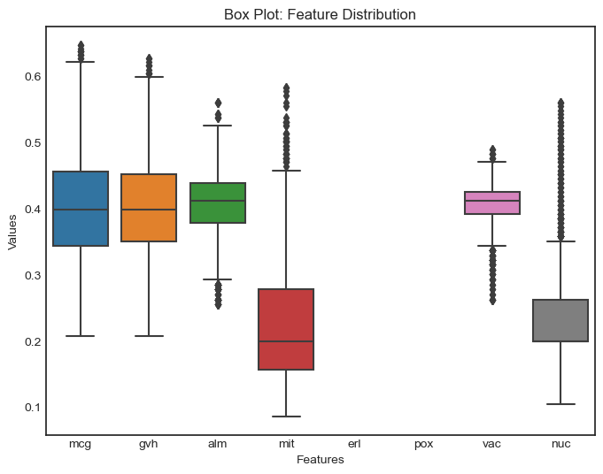

```python
# Insight Visualization with Box Plot.

plt.figure(figsize=(8, 6))
sns.boxplot(data=df_numeric.drop(columns='name'))
plt.title('Box Plot: Feature Distribution')
plt.xlabel('Features')
plt.ylabel('Values')
plt.show()
```

##### f. Data Balancing Tasks

*Some popular techniques include oversampling (e.g., SMOTE, ADASYN), undersampling (e.g., random undersampling, cluster centroid), and hybrid methods (e.g., SMOTE + Tomek links). These techniques aim to address class imbalance by either increasing the minority class samples or decreasing the majority class samples.The effect of data balancing on model evaluation parameters depends on the specific task, dataset, and imbalance severity. Balancing techniques can improve the performance of models by reducing bias towards the majority class and improving the models ability to correctly classify the minority class. It may lead to better precision, recall, F1-score, and overall accuracy for the minority class. However, its important to carefully evaluate the impact on the evaluation metrics for both classes and consider the trade-offs, as oversampling can lead to overfitting and undersampling can discard potentially valuable information.*